# Lab 4

Sydney Thompson

3/18/2021

# Joining & Tidying ISU Football Data

# Loading Data

```r
library(readxl)
library(dplyr)
```

```r
library(ggplot2)
library(tidyverse)
defense <- read_excel('/Users/sydne/Documents/ds202_hw1/cyclonesFootball2020.xlsx', sheet='Defensive')
offense <- read_excel('/Users/sydne/Documents/ds202_hw1/cyclonesFootball2020.xlsx', sheet='Offensive')
biography <- read_excel('/Users/sydne/Documents/ds202_hw1/cyclonesFootball2020.xlsx', sheet='Biography')
str(defense)
```

```
## tibble [372 x 11] (S3: tbl_df/tbl/data.frame)
##  $ Name             : chr [1:372] "Rose, Mike" "Rose, Mike" "Rose, Mike" "Rose, Mike" ...
##  $ Opponent_Opponent: chr [1:372] "Louisiana" "TCU" "Oklahoma" "Texas Tech" ...
##  $ Tackles_Solo     : chr [1:372] "2" "6" "6" "3" ...
##  $ Tackles_ASST     : chr [1:372] "4" "4" "5" "0" ...
##  $ Tackles_TFL      : chr [1:372] "1.0" "0" "1.5" "1.0" ...
##  $ Tackles_Sack     : chr [1:372] "0" "0" "0.5" "0" ...
##  $ Turnover_FF      : chr [1:372] "0" "0" "0" "0" ...
##  $ Turnover_FR      : chr [1:372] "0" "0" "0" "0" ...
##  $ Turnover_INT     : chr [1:372] "0" "1" "0" "0" ...
##  $ Pass_QBH         : chr [1:372] "0" "0" "1" "0" ...
##  $ Pass_PB          : chr [1:372] "0" "0" "0" "0" ...
```

# Part 1: Cleaning Data

# 1) The player names and opponent names are factors.

```r
as.factor(defense$Name)
```

```
##   [1] Rose, Mike         Rose, Mike         Rose, Mike
##   [4] Rose, Mike         Rose, Mike         Rose, Mike
##   [7] Rose, Mike         Rose, Mike         Rose, Mike
##  [10] Rose, Mike         Rose, Mike         Rose, Mike
##  [13] Hummel, Jake       Hummel, Jake       Hummel, Jake
##  [16] Hummel, Jake       Hummel, Jake       Hummel, Jake
##  [19] Hummel, Jake       Hummel, Jake       Hummel, Jake
##  [22] Hummel, Jake       Hummel, Jake       Hummel, Jake
##  [25] Vance, O'Rien      Vance, O'Rien      Vance, O'Rien
##  [28] Vance, O'Rien      Vance, O'Rien      Vance, O'Rien
##  [31] Vance, O'Rien      Vance, O'Rien      Vance, O'Rien
##  [34] Vance, O'Rien      Vance, O'Rien      Vance, O'Rien
##  [37] Young, Isheem      Young, Isheem      Young, Isheem
##  [40] Young, Isheem      Young, Isheem      Young, Isheem
##  [43] Young, Isheem      Young, Isheem      Young, Isheem
```

[output cut: 110 more lines]

```r
as.factor(defense$Opponent_Opponent)
```

```
##   [1] Louisiana     TCU           Oklahoma      Texas Tech    Oklahoma St.
##   [6] Kansas        Baylor        Kansas State  Texas         West Virginia
##  [11] Oklahoma      Oregon        Louisiana     TCU           Oklahoma
##  [16] Texas Tech    Oklahoma St.  Kansas        Baylor        Kansas State
##  [21] Texas         West Virginia Oklahoma      Oregon        Louisiana
##  [26] TCU           Oklahoma      Texas Tech    Oklahoma St.  Kansas
##  [31] Baylor        Kansas State  Texas         West Virginia Oklahoma
##  [36] Oregon        Louisiana     TCU           Oklahoma      Texas Tech
##  [41] Oklahoma St.  Kansas        Baylor        Kansas State  Texas
##  [46] West Virginia Oklahoma      Oregon        Louisiana     TCU
##  [51] Oklahoma      Texas Tech    Oklahoma St.  Kansas        Baylor
##  [56] Kansas State  Texas         West Virginia Oklahoma      Oregon
##  [61] Louisiana     TCU           Oklahoma      Texas Tech    Oklahoma St.
##  [66] Kansas        Baylor        West Virginia Oklahoma      Louisiana
##  [71] TCU           Oklahoma      Texas Tech    Oklahoma St.  Kansas
```

[output cut: 61 more lines]

```r
as.factor(offense$Name)
```

```
##   [1] Akers, Landen      Akers, Landen      Akers, Landen
##   [4] Akers, Landen      Akers, Landen      Akers, Landen
##   [7] Akers, Landen      Akers, Landen      Akers, Landen
##  [10] Akers, Landen      Akers, Landen      Akers, Landen
##  [13] Brock, Jirehl      Brock, Jirehl      Brock, Jirehl
##  [16] Brock, Jirehl      Brock, Jirehl      Brock, Jirehl
##  [19] Brock, Jirehl      Brock, Jirehl      Brock, Jirehl
##  [22] Brock, Jirehl      Hutchinson, Xavier Hutchinson, Xavier
##  [25] Hutchinson, Xavier Hutchinson, Xavier Hutchinson, Xavier
##  [28] Hutchinson, Xavier Hutchinson, Xavier Hutchinson, Xavier
##  [31] Hutchinson, Xavier Hutchinson, Xavier Hutchinson, Xavier
##  [34] Hutchinson, Xavier Nwangwu, Kene      Nwangwu, Kene
##  [37] Nwangwu, Kene      Nwangwu, Kene      Nwangwu, Kene
##  [40] Nwangwu, Kene      Nwangwu, Kene      Nwangwu, Kene
##  [43] Nwangwu, Kene      Nwangwu, Kene      Nwangwu, Kene
```

[output cut: 38 more lines]

```r
as.factor(offense$Opponent_Opponent)
```

```
##   [1] Louisiana     TCU           Oklahoma      Texas Tech    Oklahoma St.
##   [6] Kansas        Baylor        Kansas State  Texas         West Virginia
##  [11] Oklahoma      Oregon        Oklahoma      Texas Tech    Oklahoma St.
##  [16] Kansas        Baylor        Kansas State  Texas         West Virginia
##  [21] Oklahoma      Oregon        Louisiana     TCU           Oklahoma
##  [26] Texas Tech    Oklahoma St.  Kansas        Baylor        Kansas State
##  [31] Texas         West Virginia Oklahoma      Oregon        Louisiana
##  [36] TCU           Oklahoma      Texas Tech    Oklahoma St.  Kansas
##  [41] Baylor        Kansas State  Texas         West Virginia Oklahoma
##  [46] Oregon        Louisiana     TCU           Oklahoma      Texas Tech
##  [51] Oklahoma St.  Kansas        Baylor        Kansas State  Texas
##  [56] West Virginia Oklahoma      Oregon        Louisiana     TCU
##  [61] Oklahoma      Texas Tech    Oklahoma St.  Kansas        Baylor
##  [66] Kansas State  Texas         Oklahoma      Oregon        Louisiana
##  [71] TCU           Oklahoma      Texas Tech    Oklahoma St.  Kansas
```

[output cut: 18 more lines]

# 2) All offensive and defensive statistics are numerical. The Weight column in biogrpahy is also numeric. (Optional: Read ?across and learn to mutate multiple columns simultaneously using the across function in dplyr)

```r
defense <- defense %>% mutate(Tackles_Solo = as.numeric(Tackles_Solo))%>% na.omit
defense <- defense %>% mutate(Tackles_ASST = as.numeric(Tackles_ASST))%>% na.omit
defense <- defense %>% mutate(Tackles_TFL = as.numeric(Tackles_TFL))%>% na.omit
defense <- defense %>% mutate(Tackles_Sack = as.numeric(Tackles_Sack))%>% na.omit
defense <- defense %>% mutate(Turnover_FF = as.numeric(Turnover_FF))%>% na.omit
defense <- defense %>% mutate(Turnover_FR = as.numeric(Turnover_FR))%>% na.omit
defense <- defense %>% mutate(Turnover_INT = as.numeric(Turnover_INT))%>% na.omit
defense <- defense %>% mutate(Pass_QBH = as.numeric(Pass_QBH))%>% na.omit
defense <- defense %>% mutate(Pass_PB = as.numeric(Pass_PB))%>% na.omit
```

```r
offense <- offense %>% mutate(Receiving_REC=as.numeric(Receiving_REC))
offense <- offense %>% mutate(Receiving_YDS=as.numeric(Receiving_YDS))
offense <- offense %>% mutate(Receiving_TD=as.numeric(Receiving_TD))
offense <- offense %>% mutate(Rushing_TD=as.numeric(Rushing_TD))
offense <- offense %>% mutate(Rushing_ATT=as.numeric(Rushing_ATT))
offense <- offense %>% mutate(Rushing_YDS=as.numeric(Rushing_YDS))
offense <- offense %>% mutate(`Passing_CMP-ATT`=as.numeric(`Passing_CMP-ATT`))
offense <- offense %>%  mutate(Passing_YDS=as.numeric(Passing_YDS))
offense <- offense %>% mutate(Passing_TD=as.numeric(Passing_TD))
offense <- offense %>% mutate(Passing_INT=as.numeric(Passing_INT))
```

```r
biography <- biography %>% mutate(Weight=as.numeric(Weight))
```

# 3) Change the Height column in biography into numeric. (Hint: Use a unit that works well)

```r
biography <- biography %>% mutate(Height=as.numeric(Height)) %>% na.omit
str(defense)
```

```
## tibble [372 x 11] (S3: tbl_df/tbl/data.frame)
##  $ Name             : chr [1:372] "Rose, Mike" "Rose, Mike" "Rose, Mike" "Rose, Mike" ...
##  $ Opponent_Opponent: chr [1:372] "Louisiana" "TCU" "Oklahoma" "Texas Tech" ...
##  $ Tackles_Solo     : num [1:372] 2 6 6 3 7 4 7 4 4 2 ...
##  $ Tackles_ASST     : num [1:372] 4 4 5 0 3 1 4 3 9 3 ...
##  $ Tackles_TFL      : num [1:372] 1 0 1.5 1 1 0 1.5 2.5 1.5 0 ...
##  $ Tackles_Sack     : num [1:372] 0 0 0.5 0 0 0 0 1 0 0 ...
##  $ Turnover_FF      : num [1:372] 0 0 0 0 0 0 0 0 0 0 ...
##  $ Turnover_FR      : num [1:372] 0 0 0 0 0 0 0 0 0 0 ...
##  $ Turnover_INT     : num [1:372] 0 1 0 0 1 0 1 1 0 0 ...
##  $ Pass_QBH         : num [1:372] 0 0 1 0 0 0 2 1 0 0 ...
##  $ Pass_PB          : num [1:372] 0 0 0 0 0 1 0 0 1 0 ...
```

```r
str(offense)
```

```
## tibble [156 x 12] (S3: tbl_df/tbl/data.frame)
##  $ Name             : chr [1:156] "Akers, Landen" "Akers, Landen" "Akers, Landen" "Akers, Landen" ...
##  $ Opponent_Opponent: chr [1:156] "Louisiana" "TCU" "Oklahoma" "Texas Tech" ...
##  $ Receiving_REC    : num [1:156] 0 2 1 4 0 6 1 0 1 1 ...
##  $ Receiving_YDS    : num [1:156] 0 60 35 34 0 76 11 0 10 2 ...
##  $ Receiving_TD     : num [1:156] 0 0 0 0 0 0 0 0 0 1 ...
##  $ Rushing_ATT      : num [1:156] NA NA NA NA NA NA NA NA NA NA ...
##  $ Rushing_YDS      : num [1:156] NA NA NA NA NA NA NA NA NA NA ...
##  $ Rushing_TD       : num [1:156] NA NA NA NA NA NA NA NA NA NA ...
##  $ Passing_CMP-ATT  : num [1:156] NA NA NA NA NA NA NA NA NA NA ...
##  $ Passing_YDS      : num [1:156] NA NA NA NA NA NA NA NA NA NA ...
##  $ Passing_TD       : num [1:156] NA NA NA NA NA NA NA NA NA NA ...
##  $ Passing_INT      : num [1:156] NA NA NA NA NA NA NA NA NA NA ...
```

```r
str(biography)
```

```
## tibble [0 x 7] (S3: tbl_df/tbl/data.frame)
##  $ Name      : chr(0)
##  $ Position  : chr(0)
##  $ Height    : num(0)
##  $ Weight    : num(0)
##  $ Class     : chr(0)
##  $ Hometown  : chr(0)
##  $ Highschool: chr(0)
##  - attr(*, "na.action")= 'omit' Named int [1:116] 1 2 3 4 5 6 7 8 9 10 ...
##   ..- attr(*, "names")= chr [1:116] "1" "2" "3" "4" ...
```

# Part 2: Tidying

# 1) Reformat the offClean data frame into a tidy format using pivot_longer. The type of statistic (Receiving_REC for the number of receivings, Receiving_YDS for receiving yards, etc) is added as a new key column named stat.

```r
offtidy <- offense %>% pivot_longer(Receiving_REC:Passing_INT, names_to='stat', values_to='count')
head(offtidy)
```

```
## # A tibble: 6 x 4
##   Name          Opponent_Opponent stat          count
##   <chr>         <chr>             <chr>         <dbl>
## 1 Akers, Landen Louisiana         Receiving_REC     0
## 2 Akers, Landen Louisiana         Receiving_YDS     0
## 3 Akers, Landen Louisiana         Receiving_TD      0
## 4 Akers, Landen Louisiana         Rushing_ATT      NA
## 5 Akers, Landen Louisiana         Rushing_YDS      NA
## 6 Akers, Landen Louisiana         Rushing_TD       NA
```

# 2) Show on the distributions of the offensive statistics. The distribution of each offensive statsitic should be shown in a separate facet. Explain the patterns you see.

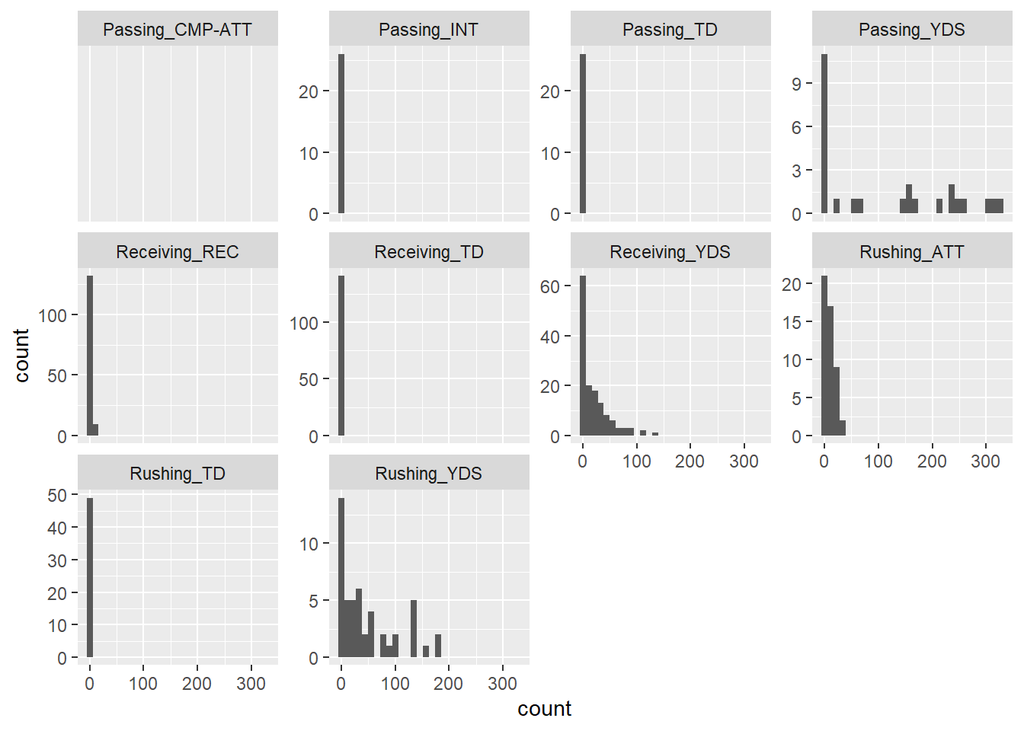

```r
ggplot(offtidy, aes(x=count)) + geom_histogram() + facet_wrap(~stat, scales='free_y')
```

# 3) Did ISU have better offense against Oregon or Oklahoma? Answer this question by creating a scatterplot with the x- and y-axes being the receiving yards of the ISU players against these two opponents. A large number of receiving yards indicates good offense.

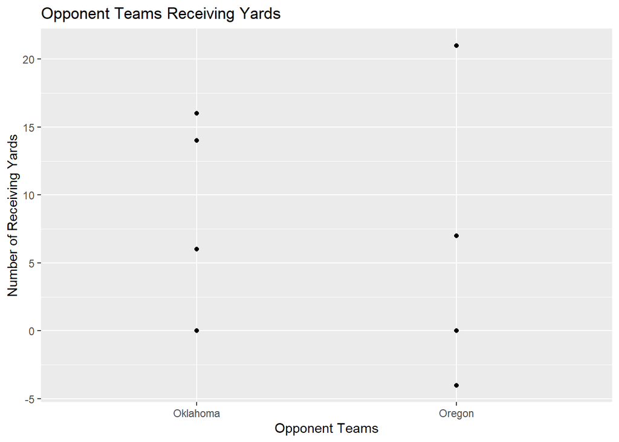

```r
off_ore_okl <- offtidy %>% filter(stat=='Receiving_YDS')
ore_okl <- off_ore_okl %>% filter(Opponent_Opponent==c('Oregon', 'Oklahoma'))
ggplot(ore_okl, aes(x=Opponent_Opponent, y=count))+geom_point()+xlab('Opponent Teams')+ylab('Number of Receiving Yards')+ggtitle('Opponent Teams Receiving Yards')
```

# 4) Separate the Hometown column into two columns, namely, the city and the state where the player comes from. Print the first few rows of these two columns. (Hint: look at the sep= argument of separate)

```r
home <- biography %>% separate(Hometown, into = c('City', 'State'), sep=',')
head(home)
```

```
## # A tibble: 0 x 8
## # ... with 8 variables: Name <chr>, Position <chr>, Height <dbl>, Weight <dbl>,
## #   Class <chr>, City <chr>, State <chr>, Highschool <chr>
```

# 5) How many players are there from each state?

```r
home %>% group_by(State) %>% count(State)
```

```
## # A tibble: 0 x 2
## # Groups:   State [0]
## # ... with 2 variables: State <chr>, n <int>
```

# Part 3: Joining Data Frames

# 1) Find which states do the ISU players (both defensive and offensive) come from. Create an appropriate numerical or graphical summary.

```r
defbiography <- inner_join(defense, home, by = 'Name')
offbiography <- inner_join(offense, home, by = 'Name')
defbiography %>% group_by(State) %>% count(State)
```

```
## # A tibble: 0 x 2
## # Groups:   State [0]
## # ... with 2 variables: State <chr>, n <int>
```

```r
offbiography %>% group_by(State) %>% count(State)
```

```
## # A tibble: 0 x 2
## # Groups:   State [0]
## # ... with 2 variables: State <chr>, n <int>
```

# 2) How does the performance of quarterback Brock Purdy relate to the performance of the ISU team?

```r
defoffense <- inner_join(defense, offense, by = "Name")
brock <- defoffense %>% filter(Name == 'Purdy, Brock')
mean(brock$Passing_YDS)
```

```
## [1] 229.1667
```

```r
mean(defoffense$Passing_YDS, na.rm=TRUE)
```

```
## [1] 125.6906
```

Brock Purdy’s average performance, measured by passing yards, is about two times greater than the average performance of the entire ISU team.

# 3) Which ISU player(s) made the biggest progress over the last year? Compare the player-level statistics (i.e. averages and totals for each player) using both the 2020 and the 2019 data here. Choose for yourself the player statistics to investigate.

```r
defense %>% group_by(Name) %>% count(Tackles_Solo)
```

```
## # A tibble: 109 x 3
## # Groups:   Name [37]
##    Name           Tackles_Solo     n
##    <chr>                 <dbl> <int>
##  1 Akers, Landen             0     9
##  2 Akers, Landen             1     3
##  3 Azunna, Arnold            0     1
##  4 Azunna, Arnold            1     5
##  5 Azunna, Arnold            2     1
##  6 Azunna, Arnold            4     2
##  7 Bailey, JaQuan            0     3
##  8 Bailey, JaQuan            1     2
##  9 Bailey, JaQuan            2     4
## 10 Bailey, JaQuan            3     2
## # ... with 99 more rows
```

```r
offense %>% group_by(Name) %>% count(Passing_YDS)
```

```
## # A tibble: 30 x 3
## # Groups:   Name [16]
##    Name               Passing_YDS     n
##    <chr>                    <dbl> <int>
##  1 Akers, Landen               NA    12
##  2 Allen, Chase                NA    11
##  3 Bitter, Aidan               NA     5
##  4 Brock, Jirehl               NA    10
##  5 Dean, Easton                NA    12
##  6 Dekkers, Hunter              0     1
##  7 Dekkers, Hunter             55     1
##  8 Dekkers, Hunter             63     1
##  9 Hall, Breece                NA    12
## 10 Hutchinson, Xavier          NA    12
## # ... with 20 more rows
```

```r
defense2019 <- read_excel('/Users/sydne/Documents/ds202_hw1/cyclonesFootball2019.xlsx', sheet='Defensive')
str(defense2019)
```

```
## tibble [502 x 11] (S3: tbl_df/tbl/data.frame)
##  $ Name             : chr [1:502] "White, Lawrence" "White, Lawrence" "White, Lawrence" "White, Lawrence" ...
##  $ Opponent_Opponent: chr [1:502] "UNI" "Iowa" "ULM" "Baylor" ...
##  $ Tackles_Solo     : chr [1:502] "4" "4" "3" "4" ...
##  $ Tackles_ASST     : chr [1:502] "4" "7" "5" "2" ...
##  $ Tackles_TFL      : chr [1:502] "0" "0" "0" "0" ...
##  $ Tackles_Sack     : chr [1:502] "0" "0" "0" "0" ...
##  $ Turnover_FF      : chr [1:502] "0" "0" "0" "0" ...
##  $ Turnover_FR      : chr [1:502] "0" "0" "0" "0" ...
##  $ Turnover_INT     : chr [1:502] "0" "0" "1" "0" ...
##  $ Pass_QBH         : chr [1:502] "1" "0" "0" "0" ...
##  $ Pass_PB          : chr [1:502] "1" "2" "0" "0" ...
```

```r
offense2019 <- read_excel('/Users/sydne/Documents/ds202_hw1/cyclonesFootball2019.xlsx', sheet='Offensive')
str(offense2019)
```

```
## tibble [195 x 12] (S3: tbl_df/tbl/data.frame)
##  $ Name             : chr [1:195] "Akers, Landen" "Akers, Landen" "Akers, Landen" "Akers, Landen" ...
##  $ Opponent_Opponent: chr [1:195] "UNI" "Iowa" "ULM" "Baylor" ...
##  $ Rushing_ATT      : chr [1:195] "0" "0" "1" "0" ...
##  $ Rushing_YDS      : chr [1:195] "0" "0" "8" "0" ...
##  $ Rushing_TD       : chr [1:195] "0" "0" "0" "0" ...
##  $ Receiving_REC    : chr [1:195] "1" "0" "0" "0" ...
##  $ Receiving_YDS    : chr [1:195] "21" "0" "0" "0" ...
##  $ Receiving_TD     : chr [1:195] "0" "0" "0" "0" ...
##  $ Passing_CMP-ATT  : chr [1:195] NA NA NA NA ...
##  $ Passing_YDS      : chr [1:195] NA NA NA NA ...
##  $ Passing_TD       : chr [1:195] NA NA NA NA ...
##  $ Passing_INT      : chr [1:195] NA NA NA NA ...
```

```r
defense2019 %>% group_by(Name) %>% count(Tackles_Solo)
```

```
## # A tibble: 135 x 3
## # Groups:   Name [43]
##    Name           Tackles_Solo     n
##    <chr>          <chr>        <int>
##  1 Akers, Landen  0                5
##  2 Akers, Landen  1                7
##  3 Akers, Landen  2                1
##  4 Allen, Chase   0               11
##  5 Allen, Chase   1                2
##  6 Azunna, Arnold 0                1
##  7 Azunna, Arnold 1                3
##  8 Azunna, Arnold 2                6
##  9 Azunna, Arnold 3                1
## 10 Bailey, JaQuan 0                2
## # ... with 125 more rows
```

```r
offense2019 %>% group_by(Name) %>% count(Passing_YDS)
```

```
## # A tibble: 32 x 3
## # Groups:   Name [17]
##    Name                Passing_YDS     n
##    <chr>               <chr>       <int>
##  1 Akers, Landen       <NA>           13
##  2 Allen, Chase        <NA>           13
##  3 Brock, Jirehl       <NA>            4
##  4 Croney Jr., Sheldon <NA>           12
##  5 Hall, Breece        <NA>           12
##  6 Jones, Deshaunte    0              12
##  7 Jones, Deshaunte    51              1
##  8 Kolar, Charlie      <NA>           13
##  9 Lang, Johnnie       <NA>           12
## 10 Milton, Tarique     <NA>           13
## # ... with 22 more rows
```